# Complementary Analysis 1 from Thesis - Cortical folding alterations in humans due to aging and diseases

Fernanda Hansen Pacheco de Moraes

30-november-2021

Description of the procedures and analysis present in Complementary Analysis 1, **Methodological robustness of image processing**, at the Doctorate Thesis presented to the Programa de Pós-Graduação em Ciência Médicas at the Instituto D’Or de Pesquisa e Ensino as a partial requirement to obtain the Doctorate Degree

Part of the data used here cannot be shared due to restrictions of the Ethic Comittee. Data can be shared upon reasonable request to the corresponding author. To fullfil these limitation, we will generate (in next versions) random data to simulate the results.

Get in touch with us (fernandahmoraes@gmail.com) in case any help is needed, our aim is to improve the code as needed!

```r
library(readr)
library(tidyverse)
library(lubridate)
library(ggpubr)
library(kableExtra)
library(broom)
```

```r
## set working directory
setwd("~/GitHub/FHPdeMoraes_thesis/Complementaryanalysis1_modelrobustness")
```

```r
## define functions

# test angular coeficinet versus theoretical value
test_coef <- function(reg, coefnum, val){
  co <- coef(summary(reg))
  tstat <- (co[coefnum,1] - val)/co[coefnum,2]
  2 * pt(abs(tstat), reg$df.residual, lower.tail = FALSE)
}

# wrap text
wrapper <- function(x, ...) paste(strwrap(x, ...), collapse = "\n")
```

# 1 Import and organize files

```r
# import subjs
tabela_sujeitos <- read_csv("tabela_sujeitos.csv",
                            col_types = cols(...1 = col_skip()))

# subjs age interval
tabela_sujeitos$Age_interval <- cut(tabela_sujeitos$Age,
                                       breaks = c(0, 5, 10, 15, 20, 25, 30, 35, 40, 45, 50, 55, 60, 65, 70, 75, 80, 85, 90, 95, 100),
                                       right = FALSE,
                                       include.lowest = TRUE)

tabela_sujeitos$Age_interval10 <- cut(tabela_sujeitos$Age,
                                         breaks = c(0, 10, 20, 30, 40, 50, 60, 70, 80, 90, 100),
                                         right = FALSE,
                                         include.lowest = TRUE)

# Select session 1
tabela_sujeitos <- tabela_sujeitos %>%
  filter(Session == "1") %>%
  dplyr::select(-c(Session))
```

```r
# import results with default config EE = 15mm
data_longcor_ses1 <- read_csv("data_longcor_ses1.txt")
```

```r
## new surfaces ----
# import results with other config EE = 5; 20; 30; 50; 75 and 100mm
data_longcor_ses1_5 <- read_csv("data_longcor_ses1_5mm.txt")
data_longcor_ses1_20 <- read_csv("data_longcor_ses1_20mm.txt")
data_longcor_ses1_30 <- read_csv("data_longcor_ses1_30mm.txt")
data_longcor_ses1_50 <- read_csv("data_longcor_ses1_50mm.txt")
data_longcor_ses1_75 <- read_csv("data_longcor_ses1_75mm.txt")
data_longcor_ses1_100 <- read_csv("data_longcor_ses1_100mm.txt")

# create variable EE diameter
data_longcor_ses1 <- data_longcor_ses1 %>%
  mutate(EEdiameter = 15)
data_longcor_ses1_5 <- data_longcor_ses1_5 %>%
  mutate(EEdiameter = 5)
data_longcor_ses1_20 <- data_longcor_ses1_20 %>%
  mutate(EEdiameter = 20)
data_longcor_ses1_30 <- data_longcor_ses1_30 %>%
  mutate(EEdiameter = 30)
data_longcor_ses1_50 <- data_longcor_ses1_50 %>%
  mutate(EEdiameter = 50)
data_longcor_ses1_75 <- data_longcor_ses1_75 %>%
  mutate(EEdiameter = 75)
data_longcor_ses1_100 <- data_longcor_ses1_100 %>%
  mutate(EEdiameter = 100)

# combine dataframes, create new variables, delete unwanted variables-c(

data <-
  full_join(data_longcor_ses1, data_longcor_ses1_5) %>% # combine files
  full_join(data_longcor_ses1_20) %>%
  full_join(data_longcor_ses1_30) %>%
  full_join(data_longcor_ses1_50) %>%
  full_join(data_longcor_ses1_75) %>%
  full_join(data_longcor_ses1_100) %>%
  mutate(
    SUBJ = SubjectID,
    hemi = Hemisphere,
    ROI = "hemisphere",
    method = "CorticalFoldingTool",
    Longitudinal_correction = "yes",
    AvgThickness = AvgCortThickness,
    ExposedArea = SmoothPialArea,
    TotalArea = PialArea,
    TotalFullArea = PialFullArea,
    WhiteSurfArea = WhiteArea,
    GMvolume = GreymatterVol
  ) %>% dplyr::select(
    -c(
      SubjectID,
      Hemisphere,
      AvgCortThickness,
      PialArea,
      SmoothPialArea,
      WhiteArea,
      GreymatterVol
    )
  )
```

```r
## FS Standard ----
data_h <-
  read_csv("data_h.csv", col_types = cols(...1 = col_skip()))

data_h <- data_h %>%
  mutate(
    SUBJ = str_sub(SUBJ_ID, 1, 7),
    Session = str_sub(SUBJ_ID, 21, 21),
    Longitudinal_correction = ifelse(str_sub(SUBJ_ID, 23, 26) == "long", "yes", "no"),
    SUBJ_ID = str_sub(SUBJ_ID, 9, 38),
    method = "FreeSurferStandard",
    EEdiameter = 15
  ) %>%
  filter(ROI == "hemisphere", Session == "1") %>%
  dplyr::select(-c(Session))
```

```r
# combine files
dados <- full_join(data, data_h) %>%
  mutate(
    # create new variables
    logAvgThickness = log10(AvgThickness),
    logTotalArea = log10(TotalArea),
    logTotalFullArea = log10(TotalFullArea),
    logExposedArea = log10(ExposedArea),
    logConvexHullArea = log10(ConvexHullArea),
    logWhiteSurfArea = log10(WhiteSurfArea),
    logGMvolume = log10(GMvolume),
    logConvexHullArea = log10(ConvexHullArea),
    localGI = TotalArea / ExposedArea,
    k = sqrt(AvgThickness) * TotalArea / (ExposedArea ^ 1.25),
    K = 1 / 4 * log10(AvgThickness ^ 2)  + log10(TotalArea) - 5 / 4 * log10(ExposedArea),
    S = 3 / 2 * log10(TotalArea) + 3 / 4 * log10(ExposedArea) - 9 /  4 * log10(AvgThickness ^
                                                                                 2) ,
    I = log10(TotalArea) + log10(ExposedArea) + log10(AvgThickness ^ 2) ,
  ) %>%
  dplyr::select(
    -c(
      PialFullArea,
      WhiteFullArea,
      SmoothPialFullArea,
      ConvexHullFullArea,
      PialFullVol,
      WhiteFullVol,
      SmoothPialFullVol,
      BrainSegVolNotVent,
      SUBJ_ID
    )
  ) %>%
  unique() # delete duplicates

# rename hemispheres
dados$hemi[dados$hemi == "left"] <- "L"
dados$hemi[dados$hemi == "right"] <- "R"

# combine tables through subject if and selected only Session 1
dados <- inner_join(tabela_sujeitos, dados)

#rename variables
colnames(dados)[which(names(dados) == "Sexo")] <- "Gender"
colnames(dados)[which(names(dados) == "Idade")] <- "Age"
colnames(dados)[which(names(dados) == "Diagnostico")] <-
  "Diagnostic"

dados$Age <- as.numeric(dados$Age)
dados$Diagnostic <- as.factor(dados$Diagnostic)
dados$Gender <- as.factor(dados$Gender)

# rename diagnostics
dados$Diagnostic <- as.character(dados$Diagnostic)

dados$Diagnostic[dados$Diagnostic == "CONTROLE"] <- "CTL"
dados$Diagnostic[dados$Diagnostic == "CCL"] <- "MCI"
dados$Diagnostic[dados$Diagnostic == "ALZ"] <- "AD"
```

```r
# remove subjects who are not in all samples

lista_subjs_CFT_yes <-
  as.data.frame(
    filter(
      dados,
      method == "CorticalFoldingTool",
      Longitudinal_correction == "yes"
    )$SUBJ
  ) %>%
  unique()

colnames(lista_subjs_CFT_yes)[1] <- "SUBJ"

lista_subjs_FS_no <-
  as.data.frame(filter(
    dados,
    method == "FreeSurferStandard",
    Longitudinal_correction == "no"
  )$SUBJ) %>%
  unique()

colnames(lista_subjs_FS_no)[1] <- "SUBJ"

lista_subjs_FS_yes <-
  as.data.frame(filter(
    dados,
    method == "FreeSurferStandard",
    Longitudinal_correction == "yes"
  )$SUBJ) %>%
  unique()

colnames(lista_subjs_FS_yes)[1] <- "SUBJ"

listas <- inner_join(lista_subjs_CFT_yes, lista_subjs_FS_no) %>%
  inner_join(lista_subjs_FS_yes)

dados <- inner_join(dados, listas)

# write.csv(dados, "dados_compmethods.csv")
```

# 2 Table 1

Number of subjects and their mean ages by diagnostic. SD for standard deviation.

```r
dados %>%
  group_by(Diagnostic) %>%
  summarise(N = n_distinct(SUBJ),
            Age = paste(signif(mean(Age), 2), "±", signif(sd(Age), 2))) %>%
  kable(digits = 2) %>%
  kable_styling()
```

| Diagnostic | N | Age |
| --- | --- | --- |
| CTL | 76 | 66 ± 8.2 |
| MCI | 36 | 72 ± 4.6 |
| AD | 13 | 77 ± 5.9 |

# 3 Table 2

```r
dados %>%
  group_by(method, Longitudinal_correction, EEdiameter) %>%
  summarise(N = n_distinct(SUBJ)) %>%
  kable(digits = 2) %>%
  kable_styling()
```

| method | Longitudinal_correction | EEdiameter | N |
| --- | --- | --- | --- |
| CorticalFoldingTool | yes | 5 | 125 |
| CorticalFoldingTool | yes | 15 | 125 |
| CorticalFoldingTool | yes | 20 | 125 |
| CorticalFoldingTool | yes | 30 | 125 |
| CorticalFoldingTool | yes | 50 | 125 |
| CorticalFoldingTool | yes | 75 | 125 |
| CorticalFoldingTool | yes | 100 | 125 |
| FreeSurferStandard | no | 15 | 125 |
| FreeSurferStandard | yes | 15 | 125 |

# 4 Results

## 4.1 Testing normality

### 4.1.1 Avg Thickness

```r
dados %>%
  mutate(method_results = method) %>%
  group_by(Diagnostic,
           method_results,
           Longitudinal_correction,
           EEdiameter) %>%
  do(tidy(shapiro.test(.$AvgThickness))) %>%
  ungroup() %>%
  kable(digits = 2) %>%
  kable_styling()
```

| Diagnostic | method_results | Longitudinal_correction | EEdiameter | statistic | p.value | method |
| --- | --- | --- | --- | --- | --- | --- |
| CTL | CorticalFoldingTool | yes | 5 | 0.99 | 0.13 | Shapiro-Wilk normality test |
| CTL | CorticalFoldingTool | yes | 15 | 0.99 | 0.13 | Shapiro-Wilk normality test |
| CTL | CorticalFoldingTool | yes | 20 | 0.99 | 0.13 | Shapiro-Wilk normality test |
| CTL | CorticalFoldingTool | yes | 30 | 0.99 | 0.13 | Shapiro-Wilk normality test |
| CTL | CorticalFoldingTool | yes | 50 | 0.99 | 0.13 | Shapiro-Wilk normality test |
| CTL | CorticalFoldingTool | yes | 75 | 0.99 | 0.13 | Shapiro-Wilk normality test |
| CTL | CorticalFoldingTool | yes | 100 | 0.99 | 0.13 | Shapiro-Wilk normality test |
| CTL | FreeSurferStandard | no | 15 | 0.99 | 0.12 | Shapiro-Wilk normality test |
| CTL | FreeSurferStandard | yes | 15 | 0.99 | 0.23 | Shapiro-Wilk normality test |
| MCI | CorticalFoldingTool | yes | 5 | 0.99 | 0.82 | Shapiro-Wilk normality test |
| MCI | CorticalFoldingTool | yes | 15 | 0.99 | 0.82 | Shapiro-Wilk normality test |
| MCI | CorticalFoldingTool | yes | 20 | 0.99 | 0.82 | Shapiro-Wilk normality test |
| MCI | CorticalFoldingTool | yes | 30 | 0.99 | 0.82 | Shapiro-Wilk normality test |
| MCI | CorticalFoldingTool | yes | 50 | 0.99 | 0.82 | Shapiro-Wilk normality test |
| MCI | CorticalFoldingTool | yes | 75 | 0.99 | 0.82 | Shapiro-Wilk normality test |
| MCI | CorticalFoldingTool | yes | 100 | 0.99 | 0.82 | Shapiro-Wilk normality test |
| MCI | FreeSurferStandard | no | 15 | 0.98 | 0.17 | Shapiro-Wilk normality test |
| MCI | FreeSurferStandard | yes | 15 | 0.99 | 0.96 | Shapiro-Wilk normality test |
| AD | CorticalFoldingTool | yes | 5 | 0.97 | 0.61 | Shapiro-Wilk normality test |
| AD | CorticalFoldingTool | yes | 15 | 0.97 | 0.61 | Shapiro-Wilk normality test |
| AD | CorticalFoldingTool | yes | 20 | 0.97 | 0.61 | Shapiro-Wilk normality test |
| AD | CorticalFoldingTool | yes | 30 | 0.97 | 0.61 | Shapiro-Wilk normality test |
| AD | CorticalFoldingTool | yes | 50 | 0.97 | 0.61 | Shapiro-Wilk normality test |
| AD | CorticalFoldingTool | yes | 75 | 0.97 | 0.61 | Shapiro-Wilk normality test |
| AD | CorticalFoldingTool | yes | 100 | 0.97 | 0.61 | Shapiro-Wilk normality test |
| AD | FreeSurferStandard | no | 15 | 0.98 | 0.81 | Shapiro-Wilk normality test |
| AD | FreeSurferStandard | yes | 15 | 0.98 | 0.93 | Shapiro-Wilk normality test |

### 4.1.2 Total Area

```r
dados %>%
  mutate(method_results = method) %>%
  group_by(Diagnostic,
           method_results,
           Longitudinal_correction,
           EEdiameter) %>%
  do(tidy(shapiro.test(.$TotalArea))) %>%
  ungroup() %>%
  kable(digits = 2) %>%
  kable_styling()
```

| Diagnostic | method_results | Longitudinal_correction | EEdiameter | statistic | p.value | method |
| --- | --- | --- | --- | --- | --- | --- |
| CTL | CorticalFoldingTool | yes | 5 | 0.97 | 0.00 | Shapiro-Wilk normality test |
| CTL | CorticalFoldingTool | yes | 15 | 0.97 | 0.00 | Shapiro-Wilk normality test |
| CTL | CorticalFoldingTool | yes | 20 | 0.97 | 0.00 | Shapiro-Wilk normality test |
| CTL | CorticalFoldingTool | yes | 30 | 0.97 | 0.00 | Shapiro-Wilk normality test |
| CTL | CorticalFoldingTool | yes | 50 | 0.97 | 0.00 | Shapiro-Wilk normality test |
| CTL | CorticalFoldingTool | yes | 75 | 0.97 | 0.00 | Shapiro-Wilk normality test |
| CTL | CorticalFoldingTool | yes | 100 | 0.97 | 0.00 | Shapiro-Wilk normality test |
| CTL | FreeSurferStandard | no | 15 | 0.98 | 0.01 | Shapiro-Wilk normality test |
| CTL | FreeSurferStandard | yes | 15 | 0.98 | 0.01 | Shapiro-Wilk normality test |
| MCI | CorticalFoldingTool | yes | 5 | 0.97 | 0.14 | Shapiro-Wilk normality test |
| MCI | CorticalFoldingTool | yes | 15 | 0.97 | 0.14 | Shapiro-Wilk normality test |
| MCI | CorticalFoldingTool | yes | 20 | 0.97 | 0.14 | Shapiro-Wilk normality test |
| MCI | CorticalFoldingTool | yes | 30 | 0.97 | 0.14 | Shapiro-Wilk normality test |
| MCI | CorticalFoldingTool | yes | 50 | 0.97 | 0.14 | Shapiro-Wilk normality test |
| MCI | CorticalFoldingTool | yes | 75 | 0.97 | 0.14 | Shapiro-Wilk normality test |
| MCI | CorticalFoldingTool | yes | 100 | 0.97 | 0.14 | Shapiro-Wilk normality test |
| MCI | FreeSurferStandard | no | 15 | 0.97 | 0.15 | Shapiro-Wilk normality test |
| MCI | FreeSurferStandard | yes | 15 | 0.97 | 0.15 | Shapiro-Wilk normality test |
| AD | CorticalFoldingTool | yes | 5 | 0.95 | 0.24 | Shapiro-Wilk normality test |
| AD | CorticalFoldingTool | yes | 15 | 0.95 | 0.24 | Shapiro-Wilk normality test |
| AD | CorticalFoldingTool | yes | 20 | 0.95 | 0.24 | Shapiro-Wilk normality test |
| AD | CorticalFoldingTool | yes | 30 | 0.95 | 0.24 | Shapiro-Wilk normality test |
| AD | CorticalFoldingTool | yes | 50 | 0.95 | 0.24 | Shapiro-Wilk normality test |
| AD | CorticalFoldingTool | yes | 75 | 0.95 | 0.24 | Shapiro-Wilk normality test |
| AD | CorticalFoldingTool | yes | 100 | 0.95 | 0.24 | Shapiro-Wilk normality test |
| AD | FreeSurferStandard | no | 15 | 0.96 | 0.44 | Shapiro-Wilk normality test |
| AD | FreeSurferStandard | yes | 15 | 0.95 | 0.28 | Shapiro-Wilk normality test |

### 4.1.3 Exposed Area

```r
dados %>%
  mutate(method_results = method) %>%
  group_by(Diagnostic,
           method_results,
           Longitudinal_correction,
           EEdiameter) %>%
  do(tidy(shapiro.test(.$ExposedArea))) %>%
  ungroup() %>%
  kable(digits = 2) %>%
  kable_styling()
```

| Diagnostic | method_results | Longitudinal_correction | EEdiameter | statistic | p.value | method |
| --- | --- | --- | --- | --- | --- | --- |
| CTL | CorticalFoldingTool | yes | 5 | 0.99 | 0.37 | Shapiro-Wilk normality test |
| CTL | CorticalFoldingTool | yes | 15 | 0.99 | 0.49 | Shapiro-Wilk normality test |
| CTL | CorticalFoldingTool | yes | 20 | 0.99 | 0.43 | Shapiro-Wilk normality test |
| CTL | CorticalFoldingTool | yes | 30 | 0.99 | 0.42 | Shapiro-Wilk normality test |
| CTL | CorticalFoldingTool | yes | 50 | 0.99 | 0.42 | Shapiro-Wilk normality test |
| CTL | CorticalFoldingTool | yes | 75 | 0.99 | 0.42 | Shapiro-Wilk normality test |
| CTL | CorticalFoldingTool | yes | 100 | 0.99 | 0.42 | Shapiro-Wilk normality test |
| CTL | FreeSurferStandard | no | 15 | 0.99 | 0.29 | Shapiro-Wilk normality test |
| CTL | FreeSurferStandard | yes | 15 | 0.99 | 0.48 | Shapiro-Wilk normality test |
| MCI | CorticalFoldingTool | yes | 5 | 0.98 | 0.40 | Shapiro-Wilk normality test |
| MCI | CorticalFoldingTool | yes | 15 | 0.98 | 0.42 | Shapiro-Wilk normality test |
| MCI | CorticalFoldingTool | yes | 20 | 0.98 | 0.39 | Shapiro-Wilk normality test |
| MCI | CorticalFoldingTool | yes | 30 | 0.98 | 0.38 | Shapiro-Wilk normality test |
| MCI | CorticalFoldingTool | yes | 50 | 0.98 | 0.38 | Shapiro-Wilk normality test |
| MCI | CorticalFoldingTool | yes | 75 | 0.98 | 0.38 | Shapiro-Wilk normality test |
| MCI | CorticalFoldingTool | yes | 100 | 0.98 | 0.38 | Shapiro-Wilk normality test |
| MCI | FreeSurferStandard | no | 15 | 0.99 | 0.58 | Shapiro-Wilk normality test |
| MCI | FreeSurferStandard | yes | 15 | 0.98 | 0.40 | Shapiro-Wilk normality test |
| AD | CorticalFoldingTool | yes | 5 | 0.92 | 0.05 | Shapiro-Wilk normality test |
| AD | CorticalFoldingTool | yes | 15 | 0.95 | 0.30 | Shapiro-Wilk normality test |
| AD | CorticalFoldingTool | yes | 20 | 0.96 | 0.31 | Shapiro-Wilk normality test |
| AD | CorticalFoldingTool | yes | 30 | 0.96 | 0.33 | Shapiro-Wilk normality test |
| AD | CorticalFoldingTool | yes | 50 | 0.96 | 0.33 | Shapiro-Wilk normality test |
| AD | CorticalFoldingTool | yes | 75 | 0.96 | 0.33 | Shapiro-Wilk normality test |
| AD | CorticalFoldingTool | yes | 100 | 0.96 | 0.33 | Shapiro-Wilk normality test |
| AD | FreeSurferStandard | no | 15 | 0.93 | 0.09 | Shapiro-Wilk normality test |
| AD | FreeSurferStandard | yes | 15 | 0.94 | 0.11 | Shapiro-Wilk normality test |

### 4.1.4 localGI

```r
dados %>%
  mutate(method_results = method) %>%
  group_by(Diagnostic,
           method_results,
           Longitudinal_correction,
           EEdiameter) %>%
  do(tidy(shapiro.test(.$localGI))) %>%
  ungroup() %>%
  kable(digits = 2) %>%
  kable_styling()
```

| Diagnostic | method_results | Longitudinal_correction | EEdiameter | statistic | p.value | method |
| --- | --- | --- | --- | --- | --- | --- |
| CTL | CorticalFoldingTool | yes | 5 | 1.00 | 0.96 | Shapiro-Wilk normality test |
| CTL | CorticalFoldingTool | yes | 15 | 0.99 | 0.42 | Shapiro-Wilk normality test |
| CTL | CorticalFoldingTool | yes | 20 | 0.99 | 0.39 | Shapiro-Wilk normality test |
| CTL | CorticalFoldingTool | yes | 30 | 0.99 | 0.37 | Shapiro-Wilk normality test |
| CTL | CorticalFoldingTool | yes | 50 | 0.99 | 0.37 | Shapiro-Wilk normality test |
| CTL | CorticalFoldingTool | yes | 75 | 0.99 | 0.37 | Shapiro-Wilk normality test |
| CTL | CorticalFoldingTool | yes | 100 | 0.99 | 0.37 | Shapiro-Wilk normality test |
| CTL | FreeSurferStandard | no | 15 | 0.98 | 0.05 | Shapiro-Wilk normality test |
| CTL | FreeSurferStandard | yes | 15 | 0.99 | 0.13 | Shapiro-Wilk normality test |
| MCI | CorticalFoldingTool | yes | 5 | 0.94 | 0.00 | Shapiro-Wilk normality test |
| MCI | CorticalFoldingTool | yes | 15 | 0.95 | 0.01 | Shapiro-Wilk normality test |
| MCI | CorticalFoldingTool | yes | 20 | 0.95 | 0.00 | Shapiro-Wilk normality test |
| MCI | CorticalFoldingTool | yes | 30 | 0.95 | 0.00 | Shapiro-Wilk normality test |
| MCI | CorticalFoldingTool | yes | 50 | 0.95 | 0.00 | Shapiro-Wilk normality test |
| MCI | CorticalFoldingTool | yes | 75 | 0.95 | 0.00 | Shapiro-Wilk normality test |
| MCI | CorticalFoldingTool | yes | 100 | 0.95 | 0.00 | Shapiro-Wilk normality test |
| MCI | FreeSurferStandard | no | 15 | 0.95 | 0.01 | Shapiro-Wilk normality test |
| MCI | FreeSurferStandard | yes | 15 | 0.96 | 0.02 | Shapiro-Wilk normality test |
| AD | CorticalFoldingTool | yes | 5 | 0.98 | 0.77 | Shapiro-Wilk normality test |
| AD | CorticalFoldingTool | yes | 15 | 0.97 | 0.64 | Shapiro-Wilk normality test |
| AD | CorticalFoldingTool | yes | 20 | 0.97 | 0.60 | Shapiro-Wilk normality test |
| AD | CorticalFoldingTool | yes | 30 | 0.97 | 0.54 | Shapiro-Wilk normality test |
| AD | CorticalFoldingTool | yes | 50 | 0.97 | 0.54 | Shapiro-Wilk normality test |
| AD | CorticalFoldingTool | yes | 75 | 0.97 | 0.54 | Shapiro-Wilk normality test |
| AD | CorticalFoldingTool | yes | 100 | 0.97 | 0.54 | Shapiro-Wilk normality test |
| AD | FreeSurferStandard | no | 15 | 0.98 | 0.85 | Shapiro-Wilk normality test |
| AD | FreeSurferStandard | yes | 15 | 0.96 | 0.42 | Shapiro-Wilk normality test |

### 4.1.5 K

```r
dados %>%
  mutate(method_results = method) %>%
  group_by(Diagnostic,
           method_results,
           Longitudinal_correction,
           EEdiameter) %>%
  do(tidy(shapiro.test(.$K))) %>%
  ungroup() %>%
  kable(digits = 2) %>%
  kable_styling()
```

| Diagnostic | method_results | Longitudinal_correction | EEdiameter | statistic | p.value | method |
| --- | --- | --- | --- | --- | --- | --- |
| CTL | CorticalFoldingTool | yes | 5 | 0.98 | 0.02 | Shapiro-Wilk normality test |
| CTL | CorticalFoldingTool | yes | 15 | 0.98 | 0.03 | Shapiro-Wilk normality test |
| CTL | CorticalFoldingTool | yes | 20 | 0.98 | 0.05 | Shapiro-Wilk normality test |
| CTL | CorticalFoldingTool | yes | 30 | 0.98 | 0.06 | Shapiro-Wilk normality test |
| CTL | CorticalFoldingTool | yes | 50 | 0.98 | 0.06 | Shapiro-Wilk normality test |
| CTL | CorticalFoldingTool | yes | 75 | 0.98 | 0.06 | Shapiro-Wilk normality test |
| CTL | CorticalFoldingTool | yes | 100 | 0.98 | 0.06 | Shapiro-Wilk normality test |
| CTL | FreeSurferStandard | no | 15 | 0.99 | 0.33 | Shapiro-Wilk normality test |
| CTL | FreeSurferStandard | yes | 15 | 0.99 | 0.12 | Shapiro-Wilk normality test |
| MCI | CorticalFoldingTool | yes | 5 | 0.98 | 0.43 | Shapiro-Wilk normality test |
| MCI | CorticalFoldingTool | yes | 15 | 0.99 | 0.59 | Shapiro-Wilk normality test |
| MCI | CorticalFoldingTool | yes | 20 | 0.98 | 0.49 | Shapiro-Wilk normality test |
| MCI | CorticalFoldingTool | yes | 30 | 0.98 | 0.51 | Shapiro-Wilk normality test |
| MCI | CorticalFoldingTool | yes | 50 | 0.98 | 0.51 | Shapiro-Wilk normality test |
| MCI | CorticalFoldingTool | yes | 75 | 0.98 | 0.51 | Shapiro-Wilk normality test |
| MCI | CorticalFoldingTool | yes | 100 | 0.98 | 0.51 | Shapiro-Wilk normality test |
| MCI | FreeSurferStandard | no | 15 | 0.98 | 0.40 | Shapiro-Wilk normality test |
| MCI | FreeSurferStandard | yes | 15 | 0.99 | 0.88 | Shapiro-Wilk normality test |
| AD | CorticalFoldingTool | yes | 5 | 0.95 | 0.27 | Shapiro-Wilk normality test |
| AD | CorticalFoldingTool | yes | 15 | 0.90 | 0.01 | Shapiro-Wilk normality test |
| AD | CorticalFoldingTool | yes | 20 | 0.90 | 0.01 | Shapiro-Wilk normality test |
| AD | CorticalFoldingTool | yes | 30 | 0.89 | 0.01 | Shapiro-Wilk normality test |
| AD | CorticalFoldingTool | yes | 50 | 0.89 | 0.01 | Shapiro-Wilk normality test |
| AD | CorticalFoldingTool | yes | 75 | 0.89 | 0.01 | Shapiro-Wilk normality test |
| AD | CorticalFoldingTool | yes | 100 | 0.89 | 0.01 | Shapiro-Wilk normality test |
| AD | FreeSurferStandard | no | 15 | 0.97 | 0.61 | Shapiro-Wilk normality test |
| AD | FreeSurferStandard | yes | 15 | 0.93 | 0.09 | Shapiro-Wilk normality test |

### 4.1.6 S

```r
dados %>%
  mutate(method_results = method) %>%
  group_by(Diagnostic,
           method_results,
           Longitudinal_correction,
           EEdiameter) %>%
  do(tidy(shapiro.test(.$S))) %>%
  ungroup() %>%
  kable(digits = 2) %>%
  kable_styling()
```

| Diagnostic | method_results | Longitudinal_correction | EEdiameter | statistic | p.value | method |
| --- | --- | --- | --- | --- | --- | --- |
| CTL | CorticalFoldingTool | yes | 5 | 0.99 | 0.46 | Shapiro-Wilk normality test |
| CTL | CorticalFoldingTool | yes | 15 | 0.99 | 0.50 | Shapiro-Wilk normality test |
| CTL | CorticalFoldingTool | yes | 20 | 0.99 | 0.50 | Shapiro-Wilk normality test |
| CTL | CorticalFoldingTool | yes | 30 | 0.99 | 0.50 | Shapiro-Wilk normality test |
| CTL | CorticalFoldingTool | yes | 50 | 0.99 | 0.50 | Shapiro-Wilk normality test |
| CTL | CorticalFoldingTool | yes | 75 | 0.99 | 0.50 | Shapiro-Wilk normality test |
| CTL | CorticalFoldingTool | yes | 100 | 0.99 | 0.50 | Shapiro-Wilk normality test |
| CTL | FreeSurferStandard | no | 15 | 0.99 | 0.56 | Shapiro-Wilk normality test |
| CTL | FreeSurferStandard | yes | 15 | 0.99 | 0.29 | Shapiro-Wilk normality test |
| MCI | CorticalFoldingTool | yes | 5 | 0.95 | 0.01 | Shapiro-Wilk normality test |
| MCI | CorticalFoldingTool | yes | 15 | 0.96 | 0.01 | Shapiro-Wilk normality test |
| MCI | CorticalFoldingTool | yes | 20 | 0.96 | 0.01 | Shapiro-Wilk normality test |
| MCI | CorticalFoldingTool | yes | 30 | 0.96 | 0.01 | Shapiro-Wilk normality test |
| MCI | CorticalFoldingTool | yes | 50 | 0.96 | 0.01 | Shapiro-Wilk normality test |
| MCI | CorticalFoldingTool | yes | 75 | 0.96 | 0.01 | Shapiro-Wilk normality test |
| MCI | CorticalFoldingTool | yes | 100 | 0.96 | 0.01 | Shapiro-Wilk normality test |
| MCI | FreeSurferStandard | no | 15 | 0.93 | 0.00 | Shapiro-Wilk normality test |
| MCI | FreeSurferStandard | yes | 15 | 0.95 | 0.01 | Shapiro-Wilk normality test |
| AD | CorticalFoldingTool | yes | 5 | 0.93 | 0.07 | Shapiro-Wilk normality test |
| AD | CorticalFoldingTool | yes | 15 | 0.93 | 0.08 | Shapiro-Wilk normality test |
| AD | CorticalFoldingTool | yes | 20 | 0.93 | 0.08 | Shapiro-Wilk normality test |
| AD | CorticalFoldingTool | yes | 30 | 0.93 | 0.08 | Shapiro-Wilk normality test |
| AD | CorticalFoldingTool | yes | 50 | 0.93 | 0.08 | Shapiro-Wilk normality test |
| AD | CorticalFoldingTool | yes | 75 | 0.93 | 0.08 | Shapiro-Wilk normality test |
| AD | CorticalFoldingTool | yes | 100 | 0.93 | 0.08 | Shapiro-Wilk normality test |
| AD | FreeSurferStandard | no | 15 | 0.94 | 0.17 | Shapiro-Wilk normality test |
| AD | FreeSurferStandard | yes | 15 | 0.94 | 0.11 | Shapiro-Wilk normality test |

### 4.1.7 I

```r
dados %>%
  mutate(method_results = method) %>%
  group_by(Diagnostic,
           method_results,
           Longitudinal_correction,
           EEdiameter) %>%
  do(tidy(shapiro.test(.$I))) %>%
  ungroup() %>%
  kable(digits = 2) %>%
  kable_styling()
```

| Diagnostic | method_results | Longitudinal_correction | EEdiameter | statistic | p.value | method |
| --- | --- | --- | --- | --- | --- | --- |
| CTL | CorticalFoldingTool | yes | 5 | 0.99 | 0.36 | Shapiro-Wilk normality test |
| CTL | CorticalFoldingTool | yes | 15 | 0.99 | 0.43 | Shapiro-Wilk normality test |
| CTL | CorticalFoldingTool | yes | 20 | 0.99 | 0.44 | Shapiro-Wilk normality test |
| CTL | CorticalFoldingTool | yes | 30 | 0.99 | 0.45 | Shapiro-Wilk normality test |
| CTL | CorticalFoldingTool | yes | 50 | 0.99 | 0.45 | Shapiro-Wilk normality test |
| CTL | CorticalFoldingTool | yes | 75 | 0.99 | 0.45 | Shapiro-Wilk normality test |
| CTL | CorticalFoldingTool | yes | 100 | 0.99 | 0.45 | Shapiro-Wilk normality test |
| CTL | FreeSurferStandard | no | 15 | 0.99 | 0.24 | Shapiro-Wilk normality test |
| CTL | FreeSurferStandard | yes | 15 | 0.99 | 0.54 | Shapiro-Wilk normality test |
| MCI | CorticalFoldingTool | yes | 5 | 0.99 | 0.91 | Shapiro-Wilk normality test |
| MCI | CorticalFoldingTool | yes | 15 | 0.99 | 0.90 | Shapiro-Wilk normality test |
| MCI | CorticalFoldingTool | yes | 20 | 0.99 | 0.89 | Shapiro-Wilk normality test |
| MCI | CorticalFoldingTool | yes | 30 | 0.99 | 0.89 | Shapiro-Wilk normality test |
| MCI | CorticalFoldingTool | yes | 50 | 0.99 | 0.89 | Shapiro-Wilk normality test |
| MCI | CorticalFoldingTool | yes | 75 | 0.99 | 0.89 | Shapiro-Wilk normality test |
| MCI | CorticalFoldingTool | yes | 100 | 0.99 | 0.89 | Shapiro-Wilk normality test |
| MCI | FreeSurferStandard | no | 15 | 0.99 | 0.81 | Shapiro-Wilk normality test |
| MCI | FreeSurferStandard | yes | 15 | 0.99 | 0.72 | Shapiro-Wilk normality test |
| AD | CorticalFoldingTool | yes | 5 | 0.96 | 0.50 | Shapiro-Wilk normality test |
| AD | CorticalFoldingTool | yes | 15 | 0.97 | 0.63 | Shapiro-Wilk normality test |
| AD | CorticalFoldingTool | yes | 20 | 0.97 | 0.64 | Shapiro-Wilk normality test |
| AD | CorticalFoldingTool | yes | 30 | 0.97 | 0.64 | Shapiro-Wilk normality test |
| AD | CorticalFoldingTool | yes | 50 | 0.97 | 0.64 | Shapiro-Wilk normality test |
| AD | CorticalFoldingTool | yes | 75 | 0.97 | 0.64 | Shapiro-Wilk normality test |
| AD | CorticalFoldingTool | yes | 100 | 0.97 | 0.64 | Shapiro-Wilk normality test |
| AD | FreeSurferStandard | no | 15 | 0.97 | 0.62 | Shapiro-Wilk normality test |
| AD | FreeSurferStandard | yes | 15 | 0.97 | 0.68 | Shapiro-Wilk normality test |

## 4.2 Comparing the usage of longitudinal correction

```r
long_comp <-
  filter(dados,
         method == "FreeSurferStandard",
         !is.na(TotalArea),
         !is.infinite(ExposedArea))

LC_status <- c(yes = "With longitudinal correction",
               no = "Without longitudinal correction")
```

### 4.2.1 Figure 1. Model application

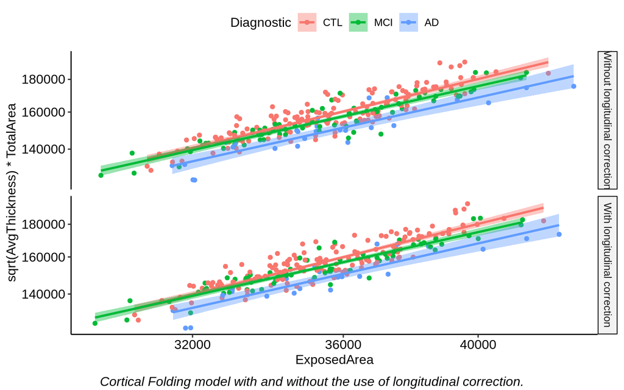

```r
## Thesis Figure 9

longcor1 <- ggplot(long_comp,
                   aes(
                     ExposedArea,
                     sqrt(AvgThickness) * TotalArea,
                     color = Diagnostic,
                     fill = Diagnostic
                   )) +
  geom_point() +
  geom_smooth(method = "lm", se = TRUE) +
  geom_abline(slope = 1.25,
              intercept = coef(lm(
                log10(TotalArea * sqrt(AvgThickness)) ~ log10(ExposedArea),
                data = dados,
                na.action = na.omit
              ))[1],
              color = "black") +
  theme_pubr() +
  facet_grid(Longitudinal_correction ~ . ,
             labeller = labeller(Longitudinal_correction = LC_status)) +
  labs(color = "Diagnostic",
       fill = "Diagnostic") +
  scale_x_log10() +
  scale_y_log10()

ggsave("longcor1.png", plot = longcor1, dpi=1200, width = 11, height = 11, units = "cm", device = "png")

longcor1 <- annotate_figure(longcor1,
                            bottom = text_grob(
                              wrapper(
                                "Cortical Folding model with and without the use of longitudinal correction.",
                                width = 100
                              ),
                              face = "italic"
                            ))

longcor1
```

### 4.2.2 Slope for each diagnostic

⍺ for each diagnostic with and without longitudinal correction. Slope ± Standard Deviation and 95% Confidence Interval.

```r
lm_fit_comp_idor <- long_comp %>%
  group_by(Diagnostic, Longitudinal_correction) %>%
  do(fit_comp_idor = tidy(lm(
    log10(TotalArea * sqrt(AvgThickness)) ~ log10(ExposedArea),
    data = .,
    na.action = na.omit
  ), conf.int = TRUE)) %>%
  unnest(cols = c(fit_comp_idor))

filter(lm_fit_comp_idor, term == "log10(ExposedArea)") %>% kable(digits = 2) %>% kable_styling()
```

| Diagnostic | Longitudinal_correction | term | estimate | std.error | statistic | p.value | conf.low | conf.high |
| --- | --- | --- | --- | --- | --- | --- | --- | --- |
| CTL | no | log10(ExposedArea) | 1.11 | 0.05 | 23.73 | 0 | 1.02 | 1.20 |
| CTL | yes | log10(ExposedArea) | 1.14 | 0.05 | 24.25 | 0 | 1.04 | 1.23 |
| MCI | no | log10(ExposedArea) | 1.03 | 0.05 | 21.38 | 0 | 0.94 | 1.13 |
| MCI | yes | log10(ExposedArea) | 1.03 | 0.05 | 22.26 | 0 | 0.94 | 1.12 |
| AD | no | log10(ExposedArea) | 1.03 | 0.10 | 10.42 | 0 | 0.83 | 1.23 |
| AD | yes | log10(ExposedArea) | 1.04 | 0.10 | 10.75 | 0 | 0.84 | 1.24 |

#### 4.2.2.1 Plot

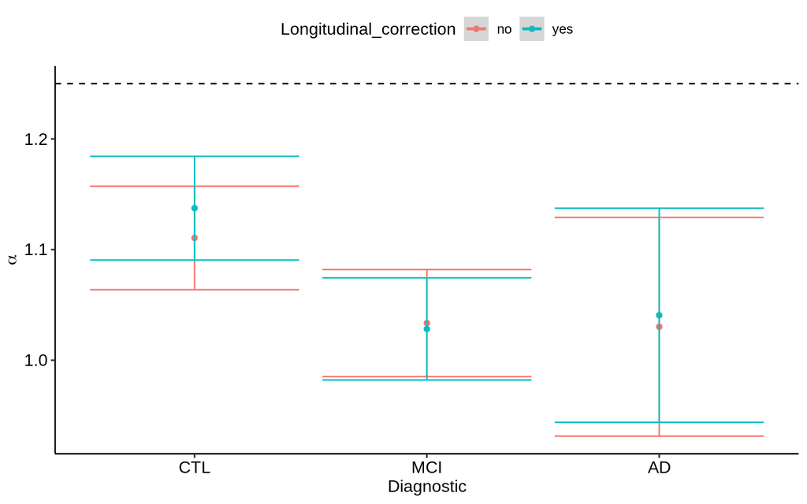

```r
ggplot(
  data = filter(lm_fit_comp_idor, term == "log10(ExposedArea)"),
  aes(x = Diagnostic,
      y = estimate, color = Longitudinal_correction, )
) +
  geom_point() +
  geom_errorbar(aes(ymin = estimate - std.error, ymax = estimate + std.error)) +
  geom_smooth(method = "lm", se = TRUE) +
  geom_hline(yintercept = 1.25, linetype = "dashed") +
  theme_pubr() +
  labs(y = expression(alpha))
```

### 4.2.3 Correlation for each variable within methodologies

Correlations for each morphological variable measured by FreeSurfer before and after the longitudinal correction.

```r
long_comp_long <- long_comp %>%
  dplyr::select(
    c(
      SUBJ,
      Diagnostic,
      hemi,
      Longitudinal_correction,
      AvgThickness,
      TotalArea,
      ExposedArea,
      localGI,
      K,
      S,
      I
    )
  ) %>%
  pivot_wider(
    names_from = Longitudinal_correction,
    values_from = c(AvgThickness,
                    TotalArea,
                    ExposedArea,
                    localGI,
                    K,
                    S,
                    I)
  )
```

#### 4.2.3.1 Avg Thickness

```r
cor.test(long_comp_long$AvgThickness_no, long_comp_long$AvgThickness_yes)
```

```
##
##  Pearson's product-moment correlation
##
## data:  long_comp_long$AvgThickness_no and long_comp_long$AvgThickness_yes
## t = 62.06, df = 246, p-value < 2.2e-16
## alternative hypothesis: true correlation is not equal to 0
## 95 percent confidence interval:
##  0.9610109 0.9761896
## sample estimates:
##       cor
## 0.9695168
```

#### 4.2.3.2 Total Area

```r
cor.test(long_comp_long$TotalArea_no, long_comp_long$TotalArea_yes)
```

```
##
##  Pearson's product-moment correlation
##
## data:  long_comp_long$TotalArea_no and long_comp_long$TotalArea_yes
## t = 212.29, df = 246, p-value < 2.2e-16
## alternative hypothesis: true correlation is not equal to 0
## 95 percent confidence interval:
##  0.9965097 0.9978834
## sample estimates:
##       cor
## 0.9972818
```

#### 4.2.3.3 Exposed Area

```r
cor.test(long_comp_long$ExposedArea_no, long_comp_long$ExposedArea_yes)
```

```
##
##  Pearson's product-moment correlation
##
## data:  long_comp_long$ExposedArea_no and long_comp_long$ExposedArea_yes
## t = 134.34, df = 246, p-value < 2.2e-16
## alternative hypothesis: true correlation is not equal to 0
## 95 percent confidence interval:
##  0.9913423 0.9947445
## sample estimates:
##       cor
## 0.9932539
```

#### 4.2.3.4 localGI

```r
cor.test(long_comp_long$localGI_no, long_comp_long$localGI_yes)
```

```
##
##  Pearson's product-moment correlation
##
## data:  long_comp_long$localGI_no and long_comp_long$localGI_yes
## t = 59.263, df = 246, p-value < 2.2e-16
## alternative hypothesis: true correlation is not equal to 0
## 95 percent confidence interval:
##  0.9574461 0.9739942
## sample estimates:
##       cor
## 0.9667165
```

#### 4.2.3.5 K

```r
cor.test(long_comp_long$K_no, long_comp_long$K_yes)
```

```
##
##  Pearson's product-moment correlation
##
## data:  long_comp_long$K_no and long_comp_long$K_yes
## t = 57.293, df = 246, p-value < 2.2e-16
## alternative hypothesis: true correlation is not equal to 0
## 95 percent confidence interval:
##  0.9546411 0.9722645
## sample estimates:
##       cor
## 0.9645115
```

#### 4.2.3.6 S

```r
cor.test(long_comp_long$S_no, long_comp_long$S_yes)
```

```
##
##  Pearson's product-moment correlation
##
## data:  long_comp_long$S_no and long_comp_long$S_yes
## t = 91.79, df = 246, p-value < 2.2e-16
## alternative hypothesis: true correlation is not equal to 0
## 95 percent confidence interval:
##  0.9816848 0.9888607
## sample estimates:
##       cor
## 0.9857133
```

#### 4.2.3.7 I

```r
cor.test(long_comp_long$I_no, long_comp_long$I_yes)
```

```
##
##  Pearson's product-moment correlation
##
## data:  long_comp_long$I_no and long_comp_long$I_yes
## t = 108.17, df = 246, p-value < 2.2e-16
## alternative hypothesis: true correlation is not equal to 0
## 95 percent confidence interval:
##  0.9867248 0.9919341
## sample estimates:
##       cor
## 0.9896505
```

## 4.3 FreeSurfer vs CFT

```r
method_comp <- filter(dados, Longitudinal_correction == "yes", EEdiameter == "15")
```

### 4.3.1 Figure 2. Model application

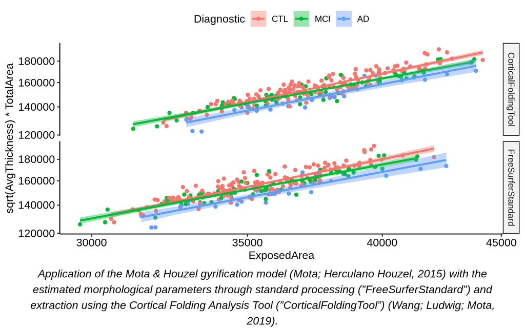

```r
## Thesis Figure

FS_CFT1 <- ggplot(method_comp,
                  aes(
                    ExposedArea,
                    sqrt(AvgThickness) * TotalArea,
                    color = Diagnostic,
                    fill = Diagnostic
                  )) +
  geom_point() +
  geom_smooth(method = "lm", se = TRUE) +
  geom_abline(slope = 1.25,
              intercept = coef(lm(
                log10(TotalArea * sqrt(AvgThickness)) ~ log10(ExposedArea),
                data = dados,
                na.action = na.omit
              ))[1],
              color = "black") +
  theme_pubr() +
  facet_grid(method ~ .) +
  labs(color = "Diagnostic",
       fill = "Diagnostic") +
  scale_x_log10() +
  scale_y_log10()

ggsave("FS_CFT1.png", plot = FS_CFT1, dpi = 1200, width = 11, height = 11, units = "cm", device = "png")

FS_CFT1 <- annotate_figure(FS_CFT1,
                           bottom = text_grob(
                             wrapper(
                               "Application of the Mota & Houzel gyrification model (Mota; Herculano Houzel, 2015) with the estimated morphological parameters through standard processing (”FreeSurferStandard”) and extraction using the Cortical Folding Analysis Tool (”CorticalFoldingTool”) (Wang; Ludwig; Mota, 2019).",
                               width = 100
                             ),
                             face = "italic"
                           ))

FS_CFT1
```

### 4.3.2 Slope for each diagnostic

```r
lm_fit_comp_idor <- method_comp %>%
  group_by(Diagnostic, method) %>%
  do(fit_comp_idor = tidy(lm(
    log10(TotalArea * sqrt(AvgThickness)) ~ log10(ExposedArea),
    data = .,
    na.action = na.omit
  ), conf.int = TRUE)) %>%
  unnest(cols = c(fit_comp_idor))

filter(lm_fit_comp_idor, term == "log10(ExposedArea)") %>% kable(digits = 2) %>% kable_styling()
```

| Diagnostic | method | term | estimate | std.error | statistic | p.value | conf.low | conf.high |
| --- | --- | --- | --- | --- | --- | --- | --- | --- |
| CTL | CorticalFoldingTool | log10(ExposedArea) | 1.17 | 0.04 | 29.07 | 0 | 1.09 | 1.25 |
| CTL | FreeSurferStandard | log10(ExposedArea) | 1.14 | 0.05 | 24.25 | 0 | 1.04 | 1.23 |
| MCI | CorticalFoldingTool | log10(ExposedArea) | 1.02 | 0.04 | 24.22 | 0 | 0.93 | 1.10 |
| MCI | FreeSurferStandard | log10(ExposedArea) | 1.03 | 0.05 | 22.26 | 0 | 0.94 | 1.12 |
| AD | CorticalFoldingTool | log10(ExposedArea) | 1.09 | 0.09 | 12.60 | 0 | 0.91 | 1.27 |
| AD | FreeSurferStandard | log10(ExposedArea) | 1.04 | 0.10 | 10.75 | 0 | 0.84 | 1.24 |

#### 4.3.2.1 Plot

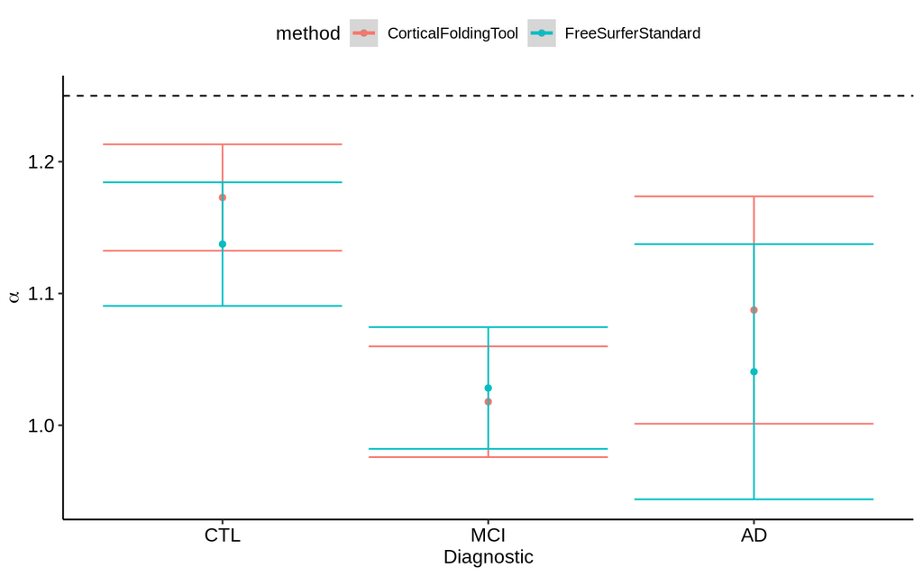

```r
ggplot(
  data = filter(lm_fit_comp_idor, term == "log10(ExposedArea)"),
  aes(x = Diagnostic,
      y = estimate, color = method)
) +
  geom_point() +
  geom_errorbar(aes(ymin = estimate - std.error, ymax = estimate + std.error)) +
  geom_smooth(method = "lm", se = TRUE) +
  geom_hline(yintercept = 1.25, linetype = "dashed") +
  theme_pubr() +
  labs(y = expression(alpha))
```

### 4.3.3 Correlation for each variable within methodologies

Correlations of each average morphological measurement by FreeSurfer and Cortical Folding Analysis Tool. All correlations are robust and with a significant p value.

```r
method_comp_long <- method_comp %>%
  dplyr::select(
    c(
      SUBJ,
      Diagnostic,
      hemi,
      method,
      AvgThickness,
      TotalArea,
      TotalFullArea,
      ExposedArea,
      localGI,
      K,
      S,
      I
    )
  ) %>%
  pivot_wider(
    names_from = method,
    values_from = c(
      AvgThickness,
      TotalArea,
      TotalFullArea,
      ExposedArea,
      localGI,
      K,
      S,
      I
    )
  )
```

#### 4.3.3.1 Avg Thickness

```r
cor.test(method_comp_long$AvgThickness_FreeSurferStandard, method_comp_long$AvgThickness_CorticalFoldingTool)
```

```
##
##  Pearson's product-moment correlation
##
## data:  method_comp_long$AvgThickness_FreeSurferStandard and method_comp_long$AvgThickness_CorticalFoldingTool
## t = 102.7, df = 246, p-value < 2.2e-16
## alternative hypothesis: true correlation is not equal to 0
## 95 percent confidence interval:
##  0.9852997 0.9910657
## sample estimates:
##       cor
## 0.9885377
```

#### 4.3.3.2 Total Area

```r
cor.test(method_comp_long$TotalArea_FreeSurferStandard, method_comp_long$TotalArea_CorticalFoldingTool)
```

```
##
##  Pearson's product-moment correlation
##
## data:  method_comp_long$TotalArea_FreeSurferStandard and method_comp_long$TotalArea_CorticalFoldingTool
## t = 456.55, df = 246, p-value < 2.2e-16
## alternative hypothesis: true correlation is not equal to 0
## 95 percent confidence interval:
##  0.9992427 0.9995410
## sample estimates:
##       cor
## 0.9994104
```

#### 4.3.3.3 Exposed Area

```r
cor.test(method_comp_long$ExposedArea_FreeSurferStandard, method_comp_long$ExposedArea_CorticalFoldingTool)
```

```
##
##  Pearson's product-moment correlation
##
## data:  method_comp_long$ExposedArea_FreeSurferStandard and method_comp_long$ExposedArea_CorticalFoldingTool
## t = 105.98, df = 246, p-value < 2.2e-16
## alternative hypothesis: true correlation is not equal to 0
## 95 percent confidence interval:
##  0.9861804 0.9916024
## sample estimates:
##       cor
## 0.9892255
```

#### 4.3.3.4 localGI

```r
cor.test(method_comp_long$localGI_FreeSurferStandard, method_comp_long$localGI_CorticalFoldingTool)
```

```
##
##  Pearson's product-moment correlation
##
## data:  method_comp_long$localGI_FreeSurferStandard and method_comp_long$localGI_CorticalFoldingTool
## t = 57.319, df = 246, p-value < 2.2e-16
## alternative hypothesis: true correlation is not equal to 0
## 95 percent confidence interval:
##  0.9546791 0.9722879
## sample estimates:
##       cor
## 0.9645414
```

#### 4.3.3.5 K

```r
cor.test(method_comp_long$K_FreeSurferStandard, method_comp_long$K_CorticalFoldingTool)
```

```
##
##  Pearson's product-moment correlation
##
## data:  method_comp_long$K_FreeSurferStandard and method_comp_long$K_CorticalFoldingTool
## t = 52.93, df = 246, p-value < 2.2e-16
## alternative hypothesis: true correlation is not equal to 0
## 95 percent confidence interval:
##  0.9473730 0.9677737
## sample estimates:
##       cor
## 0.9587916
```

#### 4.3.3.6 S

```r
cor.test(method_comp_long$S_FreeSurferStandard, method_comp_long$S_CorticalFoldingTool)
```

```
##
##  Pearson's product-moment correlation
##
## data:  method_comp_long$S_FreeSurferStandard and method_comp_long$S_CorticalFoldingTool
## t = 123.86, df = 246, p-value < 2.2e-16
## alternative hypothesis: true correlation is not equal to 0
## 95 percent confidence interval:
##  0.9898337 0.9938268
## sample estimates:
##      cor
## 0.992077
```

#### 4.3.3.7 I

```r
cor.test(method_comp_long$I_FreeSurferStandard, method_comp_long$I_CorticalFoldingTool)
```

```
##
##  Pearson's product-moment correlation
##
## data:  method_comp_long$I_FreeSurferStandard and method_comp_long$I_CorticalFoldingTool
## t = 173.7, df = 246, p-value < 2.2e-16
## alternative hypothesis: true correlation is not equal to 0
## 95 percent confidence interval:
##  0.9947980 0.9968443
## sample estimates:
##       cor
## 0.9959481
```

### 4.3.4 Difference

At the Cortical Folding Tool, the Total Full Area should be the Total Area from FreeSurfer.

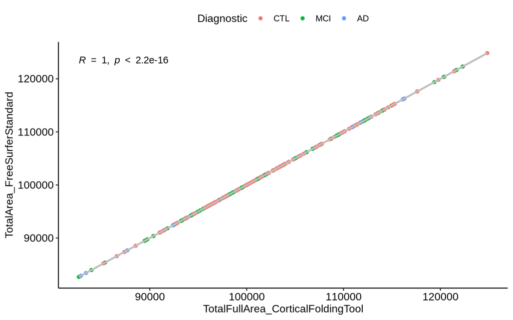

```r
ggplot(data = method_comp_long,
       aes(x = TotalFullArea_CorticalFoldingTool, y = TotalArea_FreeSurferStandard)) +
  geom_point(aes(color = Diagnostic)) +
  geom_smooth(method = "lm", color = "gray") +
  stat_cor() +
  theme_pubr()
```

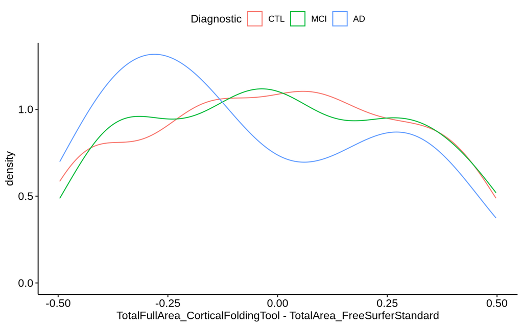

```r
ggplot(
  data = method_comp_long,
  aes(x = TotalFullArea_CorticalFoldingTool - TotalArea_FreeSurferStandard, color = Diagnostic)
) +
  geom_density() +
  theme_pubr() +
  labs(color = "Diagnostic")
```